# Applied Survey Research: Questionnaire Development and Pilot Evaluation

Monika Bagociute

september 20, 2026

## Research overview

This case study documents an applied quantitative survey research workflow, from questionnaire development and pilot testing to quantitative evaluation.

The analysis demonstrates how pilot data can be used to assess data quality, questionnaire functioning, item-level patterns, internal consistency, and differences between predefined participant groups.

### Research objectives

The pilot analysis focuses on:

- preparing and harmonising questionnaire data;
- evaluating item-level response patterns;
- assessing internal consistency of questionnaire scales;
- comparing predefined participant groups;
- identifying issues that may inform questionnaire refinement before the main study.

### Analytical workflow

The analysis follows four main stages:

1. Data preparation and questionnaire harmonisation
2. Descriptive and item-level analysis
3. Group comparisons
4. Reliability and correlation analysis

### Data note

This portfolio version is a sanitised representation of an applied research project conducted in a professional research setting. Confidential research materials, identifiable participant information, and original source files are not included in the public portfolio repository.

```r
library(readxl)
library(dplyr)
library(stringr)
library(psych)
library(ggplot2)
library(tidyr)
library(knitr)
```

### 1. Load data

```r
# The original participant-level dataset is confidential and is not included
# in the public portfolio repository.
#
# The following code generates a synthetic dataset with the same analytical
# structure as the pilot data.

set.seed(2026)

n <- 69
n_items <- 34

data <- data.frame(
  participant = 1:n,
  tto = c(rep(0, 30), rep(1, 39))
)

# Generate questionnaire responses on a 1–5 scale.
# Items are simulated with moderate correlations within conceptual scales.

simulate_scale <- function(n, n_items, mean = 3.5, sd = 0.7) {
  latent <- rnorm(n, mean = mean, sd = sd)

  responses <- sapply(
    1:n_items,
    function(i) {
      round(
        pmin(
          5,
          pmax(
            1,
            latent + rnorm(n, 0, 0.6)
          )
        )
      )
    }
  )

  as.data.frame(responses)
}

PD <- simulate_scale(n, 11, mean = 3.5)
Language <- simulate_scale(n, 14, mean = 3.7)
GC <- simulate_scale(n, 9, mean = 3.6)

data <- cbind(
  data,
  PD,
  Language,
  GC
)

names(data)[3:36] <- paste0("Q", 1:34)

Qvars <- paste0("Q", 1:34)

# Add a modest synthetic group difference to selected items.
data[data$tto == 1, c("Q12", "Q13", "Q14", "Q15")] <-
  pmin(5, data[data$tto == 1, c("Q12", "Q13", "Q14", "Q15")] + 0.3)
```

### 2. Data cleaning

The original pilot dataset required several preparation steps before analysis. These included:

- filtering responses according to the study’s participation criteria;
- harmonising questionnaire variables;
- handling structural missingness created by questionnaire branching;
- combining equivalent variables across questionnaire language versions;
- standardising response coding;
- converting questionnaire responses to numeric analysis variables.

The public portfolio version uses synthetic data and therefore does not reproduce participant-level cleaning decisions from the original research dataset.

#### Harmonise questionnaire language versions

The pilot included questionnaire versions in different languages. Equivalent items were mapped to a common set of questionnaire variables so that responses could be analysed consistently across participants.

For each questionnaire item, responses from the relevant language-specific variables were combined into a single analysis variable. Where one version was not populated because of the questionnaire routing, the corresponding response from the other language version was used.

This harmonisation step created a common set of 34 questionnaire items for the subsequent analyses.

#### Standardise response coding

Questionnaire responses were originally collected using categorical response labels. Because the questionnaire included different language versions, equivalent response categories were mapped to a common numeric scale.

The harmonised items were coded from 1 to 5, preserving the ordinal structure of the response options.

The public portfolio version uses anonymised synthetic response categories.

### 3. Sample description

The synthetic dataset contains 69 observations and represents the structure of the pilot sample used in the original analysis. Participants are divided into two predefined groups for the purpose of demonstrating the comparative analysis.

```r
kable(data.frame(
  Participants=nrow(data),
  TTO=sum(data$tto==1),
  Non_TTO=sum(data$tto==0)
))
```

| Participants | TTO | Non_TTO |
| --- | --- | --- |
| 69 | 39 | 30 |

### 4. Descriptive statistics

Descriptive statistics were used to examine the distribution and central tendency of responses across questionnaire items. Item-level means provide an initial overview of response patterns and help identify items that may warrant closer examination during pilot evaluation.

```r
describe(data[Qvars])  # Q4 and Q16
```

```
##     vars  n mean   sd median trimmed  mad min max range  skew kurtosis   se
## Q1     1 69 3.45 0.98    4.0    3.46 1.48 1.0   5   4.0 -0.32    -0.74 0.12
## Q2     2 69 3.45 0.88    4.0    3.46 1.48 1.0   5   4.0 -0.35    -0.29 0.11
## Q3     3 69 3.55 0.87    4.0    3.58 1.48 1.0   5   4.0 -0.49     0.62 0.10
## Q4     4 69 3.38 0.88    3.0    3.35 1.48 2.0   5   3.0  0.11    -0.73 0.11
## Q5     5 69 3.32 1.04    3.0    3.32 1.48 1.0   5   4.0 -0.03    -0.72 0.12
## Q6     6 69 3.45 0.92    4.0    3.47 1.48 1.0   5   4.0 -0.53     0.00 0.11
## Q7     7 69 3.48 0.92    3.0    3.51 1.48 1.0   5   4.0 -0.27     0.09 0.11
## Q8     8 69 3.48 0.93    4.0    3.49 1.48 1.0   5   4.0 -0.31    -0.48 0.11
## Q9     9 69 3.23 0.84    3.0    3.19 1.48 2.0   5   3.0  0.28    -0.54 0.10
## Q10   10 69 3.43 0.88    3.0    3.44 1.48 1.0   5   4.0 -0.18    -0.26 0.11
## Q11   11 69 3.36 0.84    3.0    3.33 1.48 2.0   5   3.0  0.14    -0.61 0.10
## Q12   12 63 3.55 0.77    3.3    3.57 1.04 2.0   5   3.0 -0.04    -0.82 0.10
## Q13   13 61 3.71 0.77    4.0    3.72 1.04 2.0   5   3.0 -0.24    -0.67 0.10
## Q14   14 62 3.65 0.90    4.0    3.73 0.74 1.0   5   4.0 -0.83     0.27 0.11
## Q15   15 65 3.75 0.76    4.0    3.79 0.44 1.3   5   3.7 -0.71     0.42 0.09
## Q16   16 69 3.71 1.06    4.0    3.77 1.48 1.0   5   4.0 -0.51    -0.71 0.13
## Q17   17 69 3.54 0.96    4.0    3.56 1.48 1.0   5   4.0 -0.25    -0.56 0.12
## Q18   18 69 3.49 0.95    4.0    3.51 1.48 1.0   5   4.0 -0.28    -0.54 0.11
## Q19   19 69 3.70 0.93    4.0    3.75 1.48 1.0   5   4.0 -0.35    -0.27 0.11
## Q20   20 69 3.70 0.85    4.0    3.75 0.00 1.0   5   4.0 -0.69     0.53 0.10
## Q21   21 69 3.75 0.90    4.0    3.82 1.48 1.0   5   4.0 -0.59     0.16 0.11
## Q22   22 69 3.68 0.95    4.0    3.74 1.48 1.0   5   4.0 -0.26    -0.43 0.11
## Q23   23 69 3.61 1.00    4.0    3.65 1.48 1.0   5   4.0 -0.21    -0.71 0.12
## Q24   24 69 3.68 0.93    4.0    3.74 1.48 1.0   5   4.0 -0.42    -0.24 0.11
## Q25   25 69 3.62 0.93    4.0    3.67 1.48 1.0   5   4.0 -0.41     0.23 0.11
## Q26   26 69 3.42 0.88    3.0    3.44 1.48 1.0   5   4.0 -0.27     0.27 0.11
## Q27   27 69 3.42 0.69    3.0    3.44 1.48 2.0   5   3.0  0.02    -0.31 0.08
## Q28   28 69 3.46 0.81    4.0    3.51 1.48 1.0   5   4.0 -0.53     0.13 0.10
## Q29   29 69 3.51 0.78    4.0    3.53 1.48 1.0   5   4.0 -0.39     0.49 0.09
## Q30   30 69 3.51 0.83    4.0    3.53 1.48 1.0   5   4.0 -0.25     0.11 0.10
## Q31   31 69 3.43 0.87    3.0    3.42 1.48 2.0   5   3.0  0.00    -0.73 0.10
## Q32   32 69 3.54 0.96    4.0    3.56 1.48 1.0   5   4.0 -0.15    -0.58 0.12
## Q33   33 69 3.52 0.85    4.0    3.54 1.48 1.0   5   4.0 -0.35     0.03 0.10
## Q34   34 69 3.59 0.93    4.0    3.61 1.48 2.0   5   3.0  0.00    -0.93 0.11
```

#### Mean response by questionnaire item

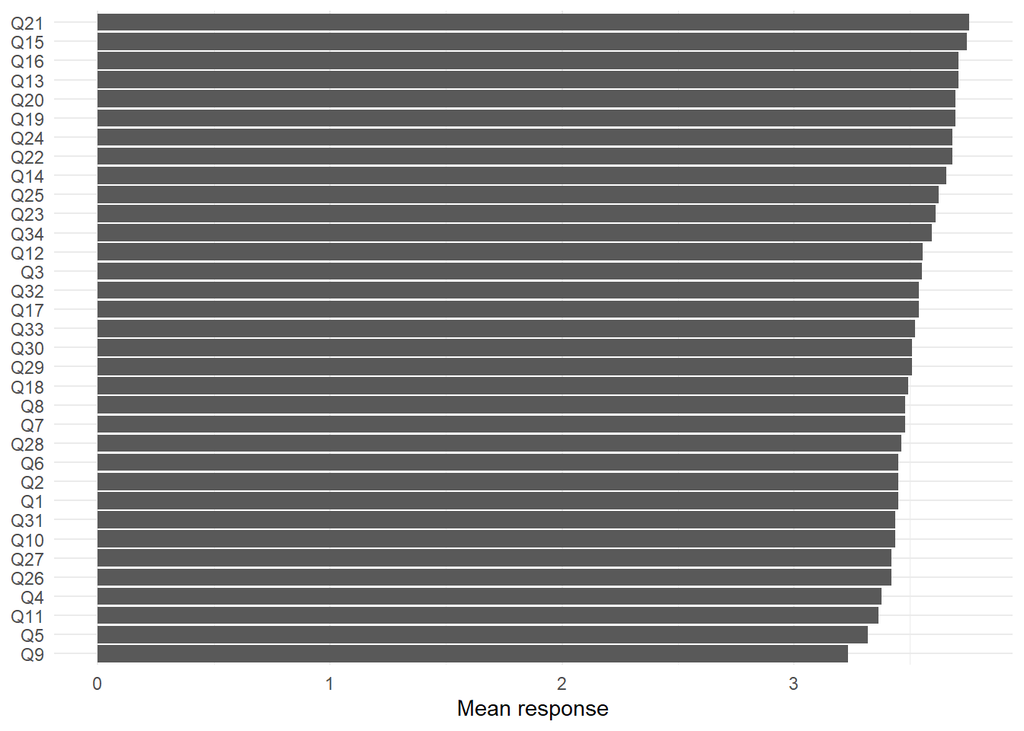

```r
means <- colMeans(data[Qvars], na.rm = TRUE)

plotdf <- data.frame(
  Question = Qvars,
  Mean = means
)

ggplot(
  plotdf,
  aes(reorder(Question, Mean), Mean)
) +
  geom_col() +
  coord_flip() +
  theme_minimal() +
  labs(
    x = NULL,
    y = "Mean response"
  )
```

### 5. Comparison between predefined groups

The pilot analysis compared questionnaire responses between two predefined participant groups. Independent-samples t-tests were used to examine item-level differences in mean responses.

These comparisons are exploratory and are intended to identify patterns that may warrant further investigation in the main study.

```r
results <- data.frame()

for(i in 1:34){

q <- paste0("Q",i)

test <- t.test(data[[q]]~data$tto)

means <- tapply(data[[q]],data$tto,mean)

results <- rbind(results,
data.frame(
Question=q,
Mean_nonTTO=means["0"],
Mean_TTO=means["1"],
t=test$statistic,
p=test$p.value))
}

kable(results,digits=3)
```

|  | Question | Mean_nonTTO | Mean_TTO | t | p |
| --- | --- | --- | --- | --- | --- |
| 0 | Q1 | 3.467 | 3.436 | 0.128 | 0.899 |
| 01 | Q2 | 3.500 | 3.410 | 0.415 | 0.680 |
| 02 | Q3 | 3.567 | 3.538 | 0.129 | 0.897 |
| 03 | Q4 | 3.367 | 3.385 | -0.084 | 0.933 |
| 04 | Q5 | 3.400 | 3.256 | 0.564 | 0.575 |
| 05 | Q6 | 3.467 | 3.436 | 0.139 | 0.890 |
| 06 | Q7 | 3.567 | 3.410 | 0.672 | 0.505 |
| 07 | Q8 | 3.767 | 3.256 | 2.327 | 0.023 |
| 08 | Q9 | 3.333 | 3.154 | 0.866 | 0.390 |
| 09 | Q10 | 3.500 | 3.385 | 0.513 | 0.610 |
| 010 | Q11 | 3.500 | 3.256 | 1.218 | 0.227 |
| 011 | Q12 | 3.500 | NA | -0.525 | 0.601 |
| 012 | Q13 | 3.700 | NA | -0.097 | 0.923 |
| 013 | Q14 | 3.567 | NA | -0.737 | 0.464 |
| 014 | Q15 | 3.800 | NA | 0.524 | 0.602 |
| 015 | Q16 | 3.800 | 3.641 | 0.616 | 0.540 |
| 016 | Q17 | 3.633 | 3.462 | 0.745 | 0.459 |
| 017 | Q18 | 3.367 | 3.590 | -0.981 | 0.330 |
| 018 | Q19 | 3.633 | 3.744 | -0.487 | 0.628 |
| 019 | Q20 | 3.600 | 3.769 | -0.794 | 0.431 |
| 020 | Q21 | 3.800 | 3.718 | 0.372 | 0.711 |
| 021 | Q22 | 3.700 | 3.667 | 0.143 | 0.887 |
| 022 | Q23 | 3.733 | 3.513 | 0.909 | 0.367 |
| 023 | Q24 | 3.733 | 3.641 | 0.405 | 0.687 |
| 024 | Q25 | 3.533 | 3.692 | -0.697 | 0.489 |
| 025 | Q26 | 3.433 | 3.410 | 0.113 | 0.911 |
| 026 | Q27 | 3.667 | 3.231 | 2.809 | 0.007 |
| 027 | Q28 | 3.533 | 3.410 | 0.651 | 0.517 |
| 028 | Q29 | 3.533 | 3.487 | 0.261 | 0.795 |
| 029 | Q30 | 3.433 | 3.564 | -0.662 | 0.510 |
| 030 | Q31 | 3.500 | 3.385 | 0.547 | 0.586 |
| 031 | Q32 | 3.767 | 3.359 | 1.791 | 0.078 |
| 032 | Q33 | 3.533 | 3.513 | 0.102 | 0.919 |
| 033 | Q34 | 3.500 | 3.667 | -0.735 | 0.465 |

#### Mean difference by questionnaire item

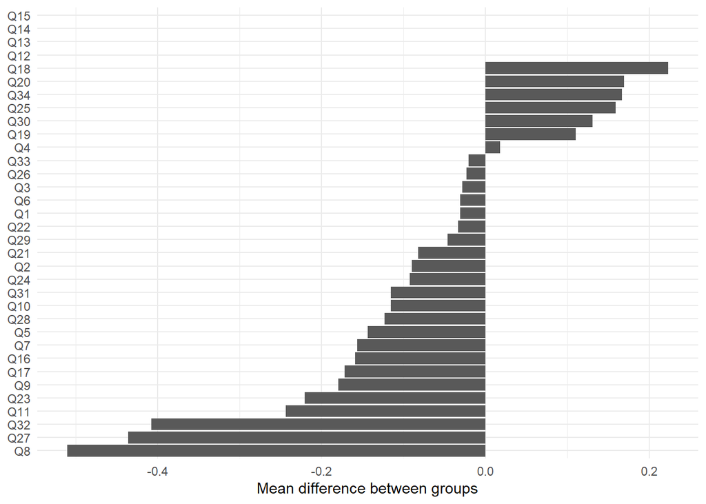

```r
plot_results <- results |>
  mutate(
    Difference = Mean_TTO - Mean_nonTTO
  )

ggplot(
  plot_results,
  aes(
    reorder(Question, Difference),
    Difference
  )
) +
  geom_col() +
  coord_flip() +
  theme_minimal() +
  labs(
    x = NULL,
    y = "Mean difference between groups"
  )
```

```r
# Adjust p-values for multiple comparisons
results$p_adjusted <- p.adjust(
  results$p,
  method = "BH"
)

kable(
  results,
  digits = 3,
  caption = "Item-level group comparisons with Benjamini-Hochberg adjusted p-values"
)
```

Item-level group comparisons with Benjamini-Hochberg adjusted p-values

|  | Question | Mean_nonTTO | Mean_TTO | t | p | p_adjusted |
| --- | --- | --- | --- | --- | --- | --- |
| 0 | Q1 | 3.467 | 3.436 | 0.128 | 0.899 | 0.933 |
| 01 | Q2 | 3.500 | 3.410 | 0.415 | 0.680 | 0.933 |
| 02 | Q3 | 3.567 | 3.538 | 0.129 | 0.897 | 0.933 |
| 03 | Q4 | 3.367 | 3.385 | -0.084 | 0.933 | 0.933 |
| 04 | Q5 | 3.400 | 3.256 | 0.564 | 0.575 | 0.933 |
| 05 | Q6 | 3.467 | 3.436 | 0.139 | 0.890 | 0.933 |
| 06 | Q7 | 3.567 | 3.410 | 0.672 | 0.505 | 0.933 |
| 07 | Q8 | 3.767 | 3.256 | 2.327 | 0.023 | 0.394 |
| 08 | Q9 | 3.333 | 3.154 | 0.866 | 0.390 | 0.933 |
| 09 | Q10 | 3.500 | 3.385 | 0.513 | 0.610 | 0.933 |
| 010 | Q11 | 3.500 | 3.256 | 1.218 | 0.227 | 0.933 |
| 011 | Q12 | 3.500 | NA | -0.525 | 0.601 | 0.933 |
| 012 | Q13 | 3.700 | NA | -0.097 | 0.923 | 0.933 |
| 013 | Q14 | 3.567 | NA | -0.737 | 0.464 | 0.933 |
| 014 | Q15 | 3.800 | NA | 0.524 | 0.602 | 0.933 |
| 015 | Q16 | 3.800 | 3.641 | 0.616 | 0.540 | 0.933 |
| 016 | Q17 | 3.633 | 3.462 | 0.745 | 0.459 | 0.933 |
| 017 | Q18 | 3.367 | 3.590 | -0.981 | 0.330 | 0.933 |
| 018 | Q19 | 3.633 | 3.744 | -0.487 | 0.628 | 0.933 |
| 019 | Q20 | 3.600 | 3.769 | -0.794 | 0.431 | 0.933 |
| 020 | Q21 | 3.800 | 3.718 | 0.372 | 0.711 | 0.933 |
| 021 | Q22 | 3.700 | 3.667 | 0.143 | 0.887 | 0.933 |
| 022 | Q23 | 3.733 | 3.513 | 0.909 | 0.367 | 0.933 |
| 023 | Q24 | 3.733 | 3.641 | 0.405 | 0.687 | 0.933 |
| 024 | Q25 | 3.533 | 3.692 | -0.697 | 0.489 | 0.933 |
| 025 | Q26 | 3.433 | 3.410 | 0.113 | 0.911 | 0.933 |
| 026 | Q27 | 3.667 | 3.231 | 2.809 | 0.007 | 0.221 |
| 027 | Q28 | 3.533 | 3.410 | 0.651 | 0.517 | 0.933 |
| 028 | Q29 | 3.533 | 3.487 | 0.261 | 0.795 | 0.933 |
| 029 | Q30 | 3.433 | 3.564 | -0.662 | 0.510 | 0.933 |
| 030 | Q31 | 3.500 | 3.385 | 0.547 | 0.586 | 0.933 |
| 031 | Q32 | 3.767 | 3.359 | 1.791 | 0.078 | 0.883 |
| 032 | Q33 | 3.533 | 3.513 | 0.102 | 0.919 | 0.933 |
| 033 | Q34 | 3.500 | 3.667 | -0.735 | 0.465 | 0.933 |

Because the analysis evaluates multiple questionnaire items separately, unadjusted p-values can increase the risk of false-positive findings. The Benjamini-Hochberg procedure is therefore used to control the false discovery rate across the item-level comparisons.

The pilot comparisons are exploratory and should not be interpreted as confirmatory evidence of group differences.

### 6. Internal consistency

Internal consistency was evaluated separately for the three questionnaire scales using Cronbach’s alpha and item-level diagnostics.

The purpose of this analysis was to assess whether items within each proposed scale showed a coherent pattern of responses and to identify potential measurement issues for consideration before the main study.

The analysis reports Cronbach’s alpha together with item-level diagnostics. These statistics are interpreted alongside the item correlations rather than as a standalone measure of scale quality.

#### Personal Development

```r
PD <- psych::alpha(data[,paste0("Q",1:11)])
PD
```

```
##
## Reliability analysis
## Call: psych::alpha(x = data[, paste0("Q", 1:11)])
##
##   raw_alpha std.alpha G6(smc) average_r S/N   ase mean   sd median_r
##       0.91      0.91    0.91      0.47 9.8 0.016  3.4 0.65     0.46
##
##     95% confidence boundaries
##          lower alpha upper
## Feldt     0.87  0.91  0.94
## Duhachek  0.88  0.91  0.94
##
##  Reliability if an item is dropped:
##     raw_alpha std.alpha G6(smc) average_r S/N alpha se  var.r med.r
## Q1       0.90      0.90    0.90      0.47 8.7    0.018 0.0064  0.46
## Q2       0.90      0.90    0.90      0.46 8.7    0.018 0.0080  0.46
## Q3       0.90      0.90    0.90      0.46 8.6    0.018 0.0081  0.46
## Q4       0.90      0.90    0.90      0.48 9.3    0.017 0.0062  0.49
## Q5       0.90      0.90    0.90      0.46 8.6    0.019 0.0075  0.46
## Q6       0.90      0.90    0.91      0.47 9.0    0.018 0.0083  0.47
## Q7       0.90      0.90    0.90      0.47 8.9    0.018 0.0065  0.46
## Q8       0.89      0.89    0.90      0.46 8.5    0.019 0.0074  0.45
## Q9       0.90      0.90    0.91      0.48 9.3    0.017 0.0077  0.49
## Q10      0.90      0.90    0.90      0.46 8.6    0.019 0.0080  0.45
## Q11      0.90      0.90    0.91      0.48 9.4    0.017 0.0059  0.49
##
##  Item statistics
##      n raw.r std.r r.cor r.drop mean   sd
## Q1  69  0.75  0.74  0.73   0.68  3.4 0.98
## Q2  69  0.74  0.75  0.72   0.68  3.4 0.88
## Q3  69  0.75  0.76  0.73   0.69  3.6 0.87
## Q4  69  0.65  0.65  0.61   0.57  3.4 0.88
## Q5  69  0.77  0.76  0.73   0.70  3.3 1.04
## Q6  69  0.70  0.70  0.66   0.62  3.4 0.92
## Q7  69  0.72  0.72  0.70   0.65  3.5 0.92
## Q8  69  0.79  0.79  0.77   0.73  3.5 0.93
## Q9  69  0.65  0.65  0.60   0.57  3.2 0.84
## Q10 69  0.76  0.76  0.74   0.70  3.4 0.88
## Q11 69  0.63  0.64  0.59   0.56  3.4 0.84
##
## Non missing response frequency for each item
##        1    2    3    4    5 miss
## Q1  0.01 0.19 0.25 0.43 0.12    0
## Q2  0.01 0.13 0.33 0.43 0.09    0
## Q3  0.03 0.04 0.39 0.42 0.12    0
## Q4  0.00 0.16 0.41 0.33 0.10    0
## Q5  0.03 0.19 0.36 0.28 0.14    0
## Q6  0.03 0.12 0.32 0.45 0.09    0
## Q7  0.03 0.07 0.42 0.35 0.13    0
## Q8  0.01 0.14 0.30 0.42 0.12    0
## Q9  0.00 0.19 0.46 0.28 0.07    0
## Q10 0.01 0.12 0.39 0.38 0.10    0
## Q11 0.00 0.14 0.43 0.33 0.09    0
```

#### Language

```r
Language <- psych::alpha(data[,paste0("Q",12:25)])
Language
```

```
##
## Reliability analysis
## Call: psych::alpha(x = data[, paste0("Q", 12:25)])
##
##   raw_alpha std.alpha G6(smc) average_r S/N   ase mean   sd median_r
##       0.94      0.94    0.95      0.53  16 0.011  3.7 0.69     0.54
##
##     95% confidence boundaries
##          lower alpha upper
## Feldt     0.92  0.94  0.96
## Duhachek  0.92  0.94  0.96
##
##  Reliability if an item is dropped:
##     raw_alpha std.alpha G6(smc) average_r S/N alpha se  var.r med.r
## Q12      0.93      0.94    0.94      0.53  15    0.011 0.0056  0.54
## Q13      0.93      0.94    0.94      0.53  15    0.011 0.0056  0.54
## Q14      0.94      0.94    0.94      0.53  15    0.011 0.0051  0.54
## Q15      0.94      0.94    0.94      0.54  15    0.011 0.0047  0.54
## Q16      0.94      0.94    0.94      0.53  15    0.011 0.0057  0.54
## Q17      0.93      0.94    0.94      0.53  15    0.011 0.0062  0.54
## Q18      0.93      0.94    0.94      0.53  14    0.011 0.0060  0.54
## Q19      0.94      0.94    0.94      0.53  15    0.011 0.0055  0.54
## Q20      0.93      0.93    0.94      0.52  14    0.012 0.0055  0.52
## Q21      0.93      0.94    0.94      0.53  14    0.012 0.0058  0.52
## Q22      0.93      0.93    0.94      0.52  14    0.012 0.0057  0.53
## Q23      0.93      0.93    0.94      0.52  14    0.012 0.0059  0.52
## Q24      0.94      0.94    0.94      0.53  15    0.011 0.0055  0.54
## Q25      0.93      0.93    0.94      0.52  14    0.012 0.0057  0.53
##
##  Item statistics
##      n raw.r std.r r.cor r.drop mean   sd
## Q12 63  0.74  0.75  0.73   0.71  3.6 0.77
## Q13 61  0.74  0.74  0.72   0.69  3.7 0.77
## Q14 62  0.71  0.70  0.68   0.65  3.7 0.90
## Q15 65  0.66  0.66  0.63   0.60  3.7 0.76
## Q16 69  0.75  0.74  0.71   0.69  3.7 1.06
## Q17 69  0.74  0.74  0.71   0.69  3.5 0.96
## Q18 69  0.75  0.76  0.74   0.70  3.5 0.95
## Q19 69  0.72  0.71  0.69   0.66  3.7 0.93
## Q20 69  0.82  0.82  0.81   0.79  3.7 0.85
## Q21 69  0.76  0.76  0.74   0.72  3.8 0.90
## Q22 69  0.80  0.80  0.78   0.75  3.7 0.95
## Q23 69  0.80  0.80  0.79   0.76  3.6 1.00
## Q24 69  0.71  0.70  0.68   0.65  3.7 0.93
## Q25 69  0.81  0.80  0.79   0.77  3.6 0.93
##
## Non missing response frequency for each item
##        1  1.3    2  2.3    3  3.3    4  4.3    5 miss
## Q12 0.00 0.00 0.03 0.08 0.24 0.21 0.14 0.24 0.06 0.09
## Q13 0.00 0.00 0.03 0.05 0.18 0.20 0.18 0.26 0.10 0.12
## Q14 0.02 0.02 0.05 0.05 0.15 0.15 0.19 0.31 0.08 0.10
## Q15 0.00 0.02 0.02 0.05 0.14 0.18 0.23 0.29 0.08 0.06
## Q16 0.01 0.00 0.16 0.00 0.17 0.00 0.41 0.00 0.25 0.00
## Q17 0.01 0.00 0.13 0.00 0.32 0.00 0.38 0.00 0.16 0.00
## Q18 0.01 0.00 0.14 0.00 0.30 0.00 0.41 0.00 0.13 0.00
## Q19 0.01 0.00 0.07 0.00 0.32 0.00 0.39 0.00 0.20 0.00
## Q20 0.01 0.00 0.07 0.00 0.25 0.00 0.54 0.00 0.13 0.00
## Q21 0.01 0.00 0.07 0.00 0.25 0.00 0.48 0.00 0.19 0.00
## Q22 0.01 0.00 0.07 0.00 0.35 0.00 0.35 0.00 0.22 0.00
## Q23 0.01 0.00 0.12 0.00 0.33 0.00 0.32 0.00 0.22 0.00
## Q24 0.01 0.00 0.09 0.00 0.29 0.00 0.42 0.00 0.19 0.00
## Q25 0.03 0.00 0.04 0.00 0.38 0.00 0.38 0.00 0.17 0.00
```

#### Global Citizenship

```r
GC <- psych::alpha(data[,paste0("Q",26:34)])
GC
```

```
##
## Reliability analysis
## Call: psych::alpha(x = data[, paste0("Q", 26:34)])
##
##   raw_alpha std.alpha G6(smc) average_r S/N   ase mean   sd median_r
##       0.88      0.88    0.88      0.45 7.4 0.021  3.5 0.61     0.44
##
##     95% confidence boundaries
##          lower alpha upper
## Feldt     0.83  0.88  0.92
## Duhachek  0.84  0.88  0.92
##
##  Reliability if an item is dropped:
##     raw_alpha std.alpha G6(smc) average_r S/N alpha se  var.r med.r
## Q26      0.86      0.86    0.86      0.44 6.3    0.025 0.0070  0.43
## Q27      0.87      0.88    0.87      0.47 7.1    0.023 0.0080  0.49
## Q28      0.87      0.87    0.87      0.45 6.6    0.024 0.0081  0.44
## Q29      0.87      0.87    0.87      0.46 6.7    0.023 0.0071  0.44
## Q30      0.86      0.86    0.85      0.43 6.0    0.026 0.0059  0.40
## Q31      0.87      0.87    0.87      0.45 6.7    0.024 0.0084  0.44
## Q32      0.86      0.86    0.86      0.44 6.4    0.025 0.0072  0.43
## Q33      0.86      0.87    0.86      0.45 6.5    0.024 0.0084  0.43
## Q34      0.88      0.88    0.87      0.47 7.0    0.022 0.0073  0.47
##
##  Item statistics
##      n raw.r std.r r.cor r.drop mean   sd
## Q26 69  0.77  0.77  0.74   0.69  3.4 0.88
## Q27 69  0.62  0.64  0.56   0.53  3.4 0.69
## Q28 69  0.70  0.71  0.66   0.62  3.5 0.81
## Q29 69  0.68  0.69  0.64   0.59  3.5 0.78
## Q30 69  0.81  0.82  0.80   0.75  3.5 0.83
## Q31 69  0.71  0.70  0.65   0.61  3.4 0.87
## Q32 69  0.76  0.75  0.72   0.67  3.5 0.96
## Q33 69  0.74  0.73  0.69   0.65  3.5 0.85
## Q34 69  0.65  0.64  0.58   0.53  3.6 0.93
##
## Non missing response frequency for each item
##        1    2    3    4    5 miss
## Q26 0.03 0.07 0.45 0.35 0.10    0
## Q27 0.00 0.07 0.48 0.41 0.04    0
## Q28 0.01 0.10 0.35 0.48 0.06    0
## Q29 0.01 0.06 0.41 0.45 0.07    0
## Q30 0.01 0.07 0.41 0.41 0.10    0
## Q31 0.00 0.14 0.38 0.38 0.10    0
## Q32 0.01 0.12 0.36 0.33 0.17    0
## Q33 0.01 0.09 0.36 0.43 0.10    0
## Q34 0.00 0.12 0.36 0.33 0.19    0
```

#### Reliability comparison

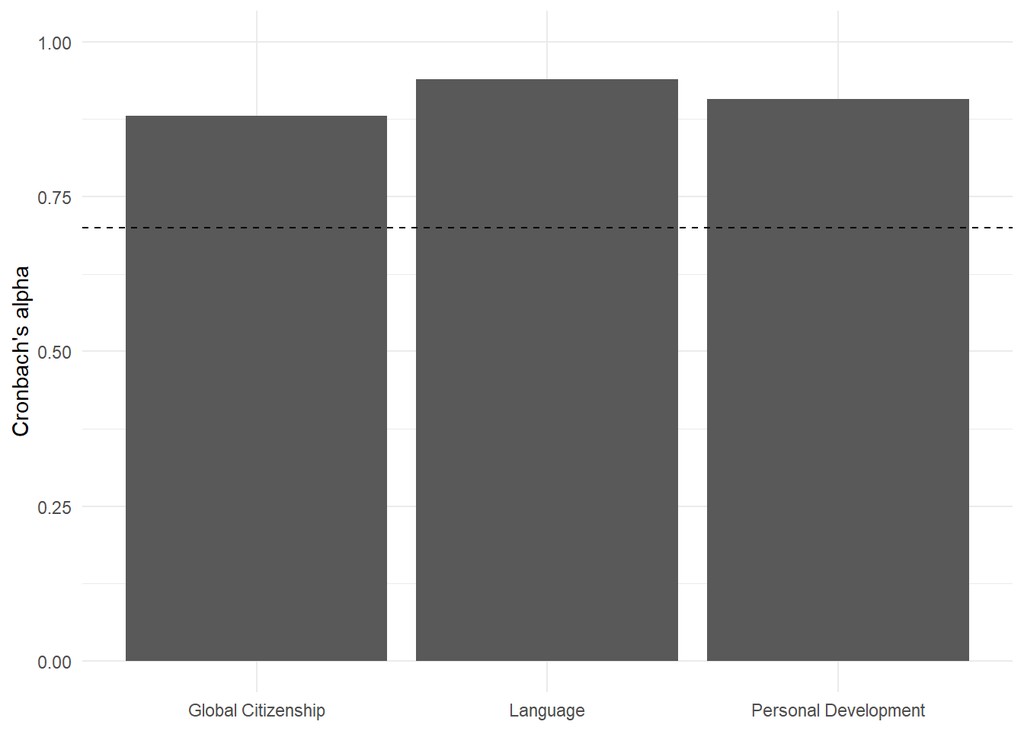

```r
alphas <- data.frame(
Scale=c("Personal Development",
"Language",
"Global Citizenship"),
Alpha=c(PD$total$raw_alpha,
Language$total$raw_alpha,
GC$total$raw_alpha))

ggplot(
  alphas,
  aes(
    x = Scale,
    y = Alpha
  )
) +
  geom_col() +
  geom_hline(
    yintercept = 0.70,
    linetype = "dashed"
  ) +
  coord_cartesian(ylim = c(0, 1)) +
  theme_minimal() +
  labs(
    x = NULL,
    y = "Cronbach's alpha"
  )
```

The reliability estimates provide an initial assessment of internal consistency across the proposed scales. In a full measurement evaluation, these results would be considered alongside item content, inter-item correlations, dimensionality, and the intended use of the scale.

### 7. Item-level correlation structure

Examining the correlation matrix provides an additional view of the relationships among questionnaire items.

This analysis can help assess whether items intended to represent related constructs show coherent response patterns and whether some items appear unusually weakly or strongly related to the rest of their scale.

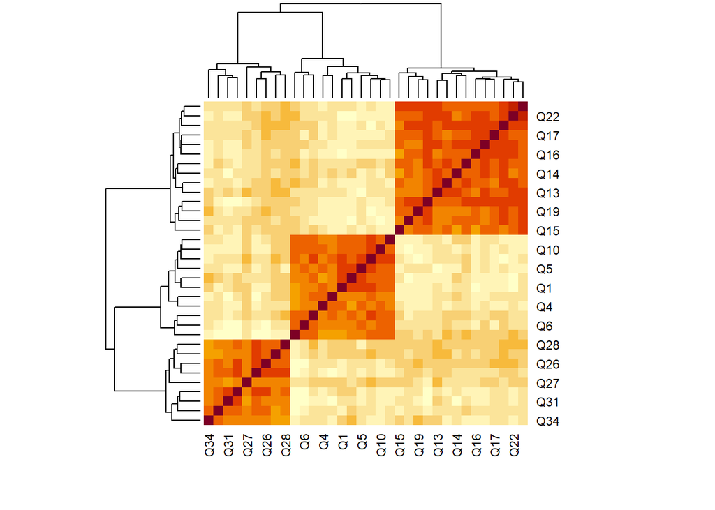

```r
corr <- cor(data[Qvars],use="pairwise.complete.obs")

heatmap(corr,scale="none")
```

## Reproducibility

The public analysis uses synthetic data generated within the R Markdown document. A fixed random seed is used so that the synthetic dataset and resulting analyses can be reproduced.

The original participant-level research data are not included in this portfolio.